# Exam : Fake News Detector - Case Study

### Export result in csv pred

```python
test_df_final.to_csv("article_classification.csv",index=True)
```

### 6. Interpretation of results

Let us plot the frequency of labels first

```python
test_df_final['label'].value_counts()
```

```
0    2011
1    1989
Name: label, dtype: int64
```

1 stands for unreliable and 0 for reliable.We have a rather good balanced classification

Visualizing the true news with Wordcloud.

```python
test_df_final[test_df_final['label']==0]
```

|  | article | label |
| --- | --- | --- |
| 2219 | ['elite', 'soccer', 'clubs', 'sign', 'gamers',... | 0 |
| 789 | ['bus', 'driver', 'pulls', 'stop', 'suicidal',... | 0 |
| 2719 | ['millions', 'risk', 'deportation', 'justices'... | 0 |
| 3681 | ['40', 'japan', 'confirmed', 'dead', 'earthqua... | 0 |
| 720 | ['good', 'cop', 'dead', 'cop', 'says', 'allege... | 0 |
| ... | ... | ... |
| 1114 | ['macy', 'close', '100', 'stores', 'erivals', ... | 0 |
| 4418 | ['jobs', 'donald', 'trump', 'celebrates', 'mas... | 0 |
| 3504 | ['rio', 'olympics', 'today', 'us', 'swimmers',... | 0 |
| 3294 | ['jim', 'mattis', 'says', 'us', 'shoulder', 's... | 0 |
| 286 | ['colombian', 'opposition', 'peace', 'deal', '... | 0 |

2011 rows × 2 columns

```python
%matplotlib inline

from wordcloud import WordCloud

all_words = ' '.join([text for text in test_df_final[test_df_final['label']==0].article])

wordcloud = WordCloud(width= 800, height= 500,
                          max_font_size = 110,
                          collocations = False).generate(all_words)
```

[figure not shown]

```python
import matplotlib.pyplot as plt

plt.figure(figsize=(10,7))
plt.imshow(wordcloud, interpolation='bilinear')
plt.axis("off")
plt.show()
```

```python
%matplotlib inline

from wordcloud import WordCloud

all_words = ' '.join([text for text in test_df_final[test_df_final['label']==1].article ])

wordcloud = WordCloud(width= 800, height= 500,
                          max_font_size = 110,
                          collocations = False).generate(all_words)
```

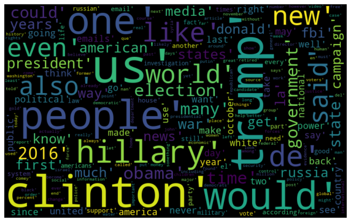

```python
import matplotlib.pyplot as plt

plt.figure(figsize=(10,7))
plt.imshow(wordcloud, interpolation='bilinear')
plt.axis("off")
plt.show()
```

Now we will plot the pareto chart to better visualize the frequencies of the words.

```python
import seaborn as sns
import nltk

def pareto(text, column_text, quantity):
    all_words = ' '.join([text for text in text[column_text]])
    token_phrase = token_space.tokenize(all_words)
    frequency = nltk.FreqDist(token_phrase)
    df_frequency = pd.DataFrame({"Word": list(frequency.keys()),
                                   "Frequency": list(frequency.values())})
    df_frequency = df_frequency.nlargest(columns = "Frequency", n = quantity)
    plt.figure(figsize=(12,8))
    ax = sns.barplot(data = df_frequency, x = "Word", y = "Frequency", color = 'blue')
    ax.set(ylabel = "Count")
    plt.show()
```

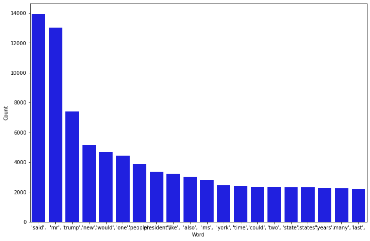

```python
#The 20 more frequent word in reliable article

pareto(test_df_final[test_df_final['label']==0], "article", 20)
```

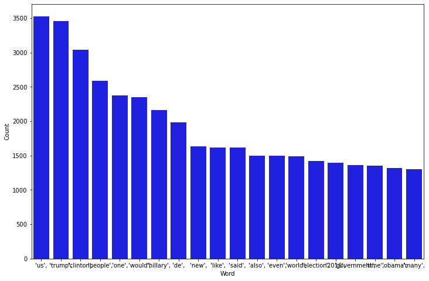

```python
#The 20 more frequent word in ureliable article

pareto(test_df_final[test_df_final['label']==1], "article", 20)
```

### 6.Recommandation

From our notebook we can conclude and recommand :

- Machine learning techniques are effective in recognising fake and not-so-fake content online.
- Alogithms such as SVM are particularly efficient
- A number of keywords and authorizations are particularly important to monitor.
- We can recommend further research on the side of deep learning models to increase the accuracy of recognition models.